# DATA202/DATA472 Assignment 3

Vincent Yu, 300390526

#### Assignment Questions

**Q1. (14 Marks)**

Answer the following questions using the `Motor_Vehicles.csv` dataset. You can use either the `dplyr` library **OR** the base `R` functions. (You do not need to show both methods. Just choose one.)

Read the file into `R`. If you using `dplyr`, also convert the data frame to a tibble.

```r
library(dplyr)
vehicles <- read.csv("Motor_Vehicles.csv", stringsAsFactors = FALSE)
vehicles <- as_tibble(vehicles) # Only if using "dplyr".
str(vehicles)
```

```
## tibble[,27] [5,000 × 27] (S3: tbl_df/tbl/data.frame)
##  $ OBJECTID                   : int [1:5000] 6001 6002 6003 6004 6005 6006 6007 6008 6009 6010 ...
##  $ BASIC_COLOUR               : chr [1:5000] "WHITE" "SILVER" "GREY" "BLUE" ...
##  $ BODY_TYPE                  : chr [1:5000] "STATION WAGON" "STATION WAGON" "HATCHBACK" "HATCHBACK" ...
##  $ CC_RATING                  : int [1:5000] 2199 2354 2261 1798 2990 0 1990 1496 3199 2351 ...
##  $ CHASSIS7                   : chr [1:5000] "" "" "" "" ...
##  $ FIRST_NZ_REGISTRATION_YEAR : int [1:5000] 2011 2012 2009 2008 2012 2012 2011 2010 2012 2011 ...
##  $ FIRST_NZ_REGISTRATION_MONTH: int [1:5000] 9 1 4 10 4 3 4 3 4 6 ...
##  $ GROSS_VEHICLE_MASS         : int [1:5000] 2510 2270 2165 1805 1795 2000 1685 1325 3200 2505 ...
##  $ HEIGHT                     : int [1:5000] 0 0 0 0 0 0 0 0 0 0 ...
##  $ IMPORT_STATUS              : chr [1:5000] "NEW" "NEW" "NEW" "NEW" ...
##  $ MAKE                       : chr [1:5000] "KIA" "HONDA" "FORD" "TOYOTA" ...
##  $ MODEL                      : chr [1:5000] "SORENTO" "ODYSSEY" "MONDEO" "COROLLA" ...
##  $ MOTIVE_POWER               : chr [1:5000] "DIESEL" "PETROL" "PETROL" "PETROL" ...
##  $ NUMBER_OF_AXLES            : int [1:5000] 0 2 2 2 2 2 2 2 2 0 ...
##  $ NUMBER_OF_SEATS            : int [1:5000] 7 7 5 5 5 0 5 5 5 3 ...
##  $ NZ_ASSEMBLED               : chr [1:5000] "IMPORTED BUILT-UP" "IMPORTED BUILT-UP" "IMPORTED BUILT-UP" "IMPORTED BUILT-UP" ...
##  $ ORIGINAL_COUNTRY           : chr [1:5000] "SOUTH KOREA" "JAPAN" "BELGIUM" "JAPAN" ...
##  $ POWER_RATING               : int [1:5000] 145 133 118 100 0 0 0 0 147 99 ...
##  $ PREVIOUS_COUNTRY           : chr [1:5000] "NONE" "NONE" "NONE" "NONE" ...
##  $ ROAD_TRANSPORT_CODE        : chr [1:5000] "" "" "" "" ...
##  $ SUBMODEL                   : chr [1:5000] "2.2 DIESEL AUTO EX" "S" "MONDEO ZETEC 2.3 AUT" "1.8P GX HATCH 5 4A" ...
##  $ TLA                        : chr [1:5000] "DUNEDIN CITY" "HAURAKI DISTRICT" "KAPITI COAST DISTRICT" "CHRISTCHURCH CITY" ...
##  $ TRANSMISSION_TYPE          : chr [1:5000] "6-GEAR AUTO" "5-GEAR AUTO" "6-GEAR AUTO" "4-GEAR AUTO" ...
##  $ VDAM_WEIGHT                : int [1:5000] 0 0 0 0 0 0 0 0 0 0 ...
##  $ VEHICLE_TYPE               : chr [1:5000] "PASSENGER CAR/VAN" "PASSENGER CAR/VAN" "PASSENGER CAR/VAN" "PASSENGER CAR/VAN" ...
##  $ VEHICLE_USAGE              : chr [1:5000] "PRIVATE PASSENGER" "PRIVATE PASSENGER" "PRIVATE PASSENGER" "PRIVATE PASSENGER" ...
##  $ VEHICLE_YEAR               : int [1:5000] 2011 2012 2009 2008 2005 2012 2003 2001 2012 2011 ...
```

```r
#names(vehicles)
```

1. Find the number of vehicles registered in Lower Hutt that have manual transmission. (The `grepl` function may prove useful.) [3 marks]

```r
vehicles.lowerhutt = vehicles[grepl(pattern ="LOWER HUTT", vehicles$TLA),]
vehicles.lowerhutt.manual = vehicles.lowerhutt[grepl(pattern = "MANUAL", vehicles.lowerhutt$TRANSMISSION_TYPE),]
nrow(vehicles.lowerhutt.manual)
```

```
## [1] 9
```

2. Find out how many grey or blue vehicles have been imported from Germany and registered in New Zealand before 2007. [3 marks]

```r
vehicles.color = filter(vehicles, vehicles$BASIC_COLOUR %in% c("GREY","BLUE"))
vehicles.color.german = filter(vehicles.color, vehicles.color$ORIGINAL_COUNTRY =="GERMANY")
vehicles.color.german.2007 = filter(vehicles.color.german, FIRST_NZ_REGISTRATION_YEAR < 2007)
result = nrow(vehicles.color.german.2007)
result
```

```
## [1] 18
```

3. Produce a table summarising all the different Mazda models in the dataset with gross vehicle mass that is greater than 0. Give the model name, mean gross vehicle mass, and the earliest and latest vehicle year for each model. [5 marks]

```r
vehicles.mazda.grossMass = filter(vehicles, vehicles$MAKE =="MAZDA", vehicles$GROSS_VEHICLE_MASS >0)
vehicles.mazda.grossMass.model = group_by(vehicles.mazda.grossMass, vehicles.mazda.grossMass$MODEL)
summarise(vehicles.mazda.grossMass.model, Mean_gross_mass = mean(GROSS_VEHICLE_MASS), earliest= min(VEHICLE_YEAR), latest=max(VEHICLE_YEAR))
```

```
## # A tibble: 21 x 4
##    `vehicles.mazda.grossMass$MODEL` Mean_gross_mass earliest latest
##    <chr>                                      <dbl>    <int>  <int>
##  1 626                                        1904      2001   2001
##  2 ATENZA                                     1667.     2002   2007
##  3 AXELA                                      1531.     2003   2008
##  4 BONGO                                      2250      2001   2003
##  5 BOUNTY                                     2868      2005   2006
##  6 BT-50                                      3047.     2008   2013
##  7 CAPELLA                                    1602.     1999   2000
##  8 CX-5                                       2134      2012   2012
##  9 CX7                                        2155.     2007   2011
## 10 CX9                                        2661      2012   2012
## # … with 11 more rows
```

4. Produce a contingency table giving the number of vehicles for every combination of make and power type (`MOTIVE_POWER`). Restrict the table to the 10 makes with the most vehicles using diesel power, and show the power types for those makes. [3 marks]

```r
make_power.table = table(vehicles$MAKE, vehicles$MOTIVE_POWER)
make_power.table.top = order(make_power.table[, "DIESEL"], decreasing = TRUE)
make_power.table.top10 = make_power.table.top[1:10]
make_power.table[make_power.table.top10,]
```

```
##
##                  DIESEL ELECTRIC LPG PETROL
##   TOYOTA       0    180        0   1    865
##   FORD         0     62        0   0    389
##   MITSUBISHI   0     40        0   0    233
##   NISSAN       0     38        0   0    288
##   HYUNDAI      0     36        0   0     76
##   HOLDEN       0     29        0   0    259
##   MAZDA        0     27        0   0    383
##   VOLKSWAGEN   0     19        0   0     82
##   AUDI         0     14        0   0     36
##   BMW          0     13        0   0    111
```

```r
result = make_power.table[make_power.table.top10,]     # the result stored in result table
```

**Q2. (17 Marks)**

Answer the following questions using the `Food_Prices.csv` dataset.

Read the file into `R`.

1. Reduce the dataset to only items (`Item`) measured in mililitres (“ml”), and check this by displaying a list of the first 10 unique item names in the reduced dataset. [2 marks]

```r
food_prices <- read.csv("Food_Prices.csv", stringsAsFactors = FALSE)
food_prices <- as_tibble(food_prices) # Only if using "dplyr".
str(food_prices)
```

```
## tibble[,7] [21,933 × 7] (S3: tbl_df/tbl/data.frame)
##  $ Item.ID   : chr [1:21933] "CPIM.SAP0100" "CPIM.SAP0100" "CPIM.SAP0100" "CPIM.SAP0100" ...
##  $ Data_value: num [1:21933] 3.11 2.78 2.43 2.42 3.04 3.24 3.27 3.18 3.74 4.21 ...
##  $ Units     : chr [1:21933] "Dollars" "Dollars" "Dollars" "Dollars" ...
##  $ Item      : chr [1:21933] "Oranges, 1kg" "Oranges, 1kg" "Oranges, 1kg" "Oranges, 1kg" ...
##  $ Year      : int [1:21933] 2006 2006 2006 2006 2006 2006 2006 2007 2007 2007 ...
##  $ Month_num : int [1:21933] 6 7 8 9 10 11 12 1 2 3 ...
##  $ Month     : chr [1:21933] "June" "July" "August" "September" ...
```

```r
food_prices.reduced = food_prices[grepl(pattern = "ml", food_prices$Item),]
unique(food_prices.reduced$Item)
```

```
## [1] "Bottled water, 750ml"              "Breakfast drink, 250ml, 6 pack"
## [3] "Cream, 300ml - Cheapest Available" "Soft drinks, 600ml"
## [5] "Soy sauce, 300ml"                  "Sports energy drinks, 350ml"
## [7] "Sports energy drinks, 250ml"       "Vinegar, 750ml"
## [9] "Mayonnaise, 380ml"
```

2. Make a new data frame/tibble from the reduced dataset (produced in part (a)) that contains only prices for the month of December. Output the tail of this data frame/tibble [1 mark]

```r
food_prices.reduced.December = filter(food_prices.reduced, Month=="December")
tail(food_prices.reduced.December)
```

```
## # A tibble: 6 x 7
##   Item.ID      Data_value Units   Item               Year Month_num Month
##   <chr>             <dbl> <chr>   <chr>             <int>     <int> <chr>
## 1 CPIM.SAP0265       3.31 Dollars Mayonnaise, 380ml  2013        12 Decemb…
## 2 CPIM.SAP0265       2.89 Dollars Mayonnaise, 380ml  2014        12 Decemb…
## 3 CPIM.SAP0265       3.2  Dollars Mayonnaise, 380ml  2015        12 Decemb…
## 4 CPIM.SAP0265       3.28 Dollars Mayonnaise, 380ml  2016        12 Decemb…
## 5 CPIM.SAP0265       2.84 Dollars Mayonnaise, 380ml  2017        12 Decemb…
## 6 CPIM.SAP0265       2.84 Dollars Mayonnaise, 380ml  2018        12 Decemb…
```

3. Create a table that gives the median price of all the items measured in mililitres for the month of December **for each year**. (You may make use of the data frame/tibble you created in part (b).) Display the table, and store that table as a new tibble/data frame. Note that you do not need to convert the prices into dollar prices (i.e., attach a ‘$’ to the front of the number). Just display them as numbers. [2 marks]

```r
fp.reduced.Dec.median = food_prices.reduced.December %>%
                        group_by(Year)%>% # group by year
                        summarise(Median_Value=median(Data_value, na.rm= TRUE)) # use median to cal the median

print(fp.reduced.Dec.median, n=nrow(fp.reduced.Dec.median))
```

```
## # A tibble: 13 x 2
##     Year Median_Value
##    <int>        <dbl>
##  1  2006         2.40
##  2  2007         2.02
##  3  2008         2.16
##  4  2009         2.32
##  5  2010         2.47
##  6  2011         2.31
##  7  2012         2.44
##  8  2013         2.56
##  9  2014         2.78
## 10  2015         2.45
## 11  2016         2.46
## 12  2017         2.61
## 13  2018         2.65
```

4. Use the table you just created to produce a line plot of median price by year, using the `ggplot` function. Be sure to provide an informative title and axis labels for the line plot. [3 marks]

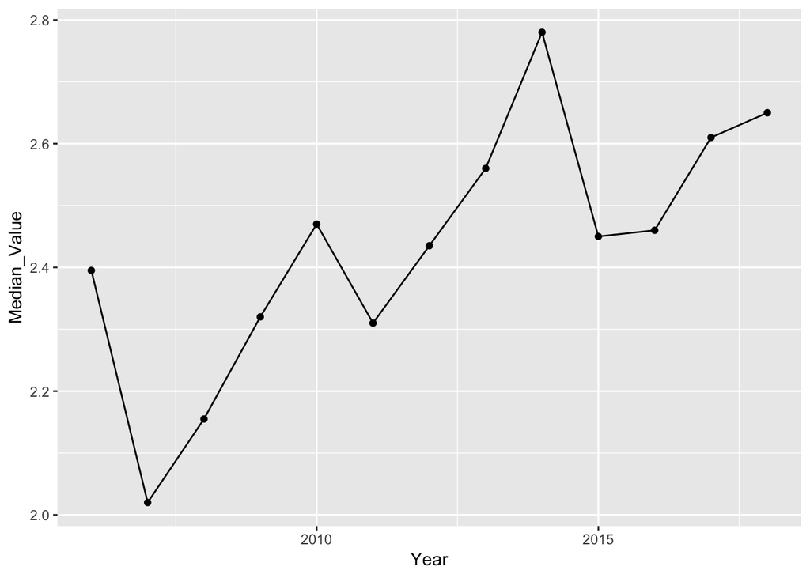

```r
library(ggplot2)
ggplot(fp.reduced.Dec.median, aes(x=Year, y= Median_Value)) + geom_line() +geom_point()
```

5. Go back to the reduced dataset of items measured in mililitres (produced in part (a)). Reduce it to just the 2012 data. [1 mark]

```r
fp.2012 = filter(food_prices.reduced, Year==2012)
fp.2012
```

```
## # A tibble: 72 x 7
##    Item.ID     Data_value Units   Item              Year Month_num Month
##    <chr>            <dbl> <chr>   <chr>            <int>     <int> <chr>
##  1 CPIM.SAP01…       2.05 Dollars Bottled water, …  2012         1 January
##  2 CPIM.SAP01…       2.17 Dollars Bottled water, …  2012         2 February
##  3 CPIM.SAP01…       2.13 Dollars Bottled water, …  2012         3 March
##  4 CPIM.SAP01…       2.06 Dollars Bottled water, …  2012         4 April
##  5 CPIM.SAP01…       2.12 Dollars Bottled water, …  2012         5 May
##  6 CPIM.SAP01…       2.11 Dollars Bottled water, …  2012         6 June
##  7 CPIM.SAP01…       2.19 Dollars Bottled water, …  2012         7 July
##  8 CPIM.SAP01…       2.16 Dollars Bottled water, …  2012         8 August
##  9 CPIM.SAP01…       2.16 Dollars Bottled water, …  2012         9 Septemb…
## 10 CPIM.SAP01…       2.21 Dollars Bottled water, …  2012        10 October
## # … with 62 more rows
```

6. Select three of the items measured in mililitres in 2012. Again using `ggplot`, plot a bar chart showing prices for these items for each month side-by-side and in different colours. Be sure to provide an informative title and axis labels for the bar chart, and use a colourblind-friendly palette.

```r
distinct(fp.2012, Item)
```

```
## # A tibble: 6 x 1
##   Item
##   <chr>
## 1 Bottled water, 750ml
## 2 Cream, 300ml - Cheapest Available
## 3 Soft drinks, 600ml
## 4 Soy sauce, 300ml
## 5 Vinegar, 750ml
## 6 Mayonnaise, 380ml
```

For this question, I chose Bottled water, Cream and Soft drinks.

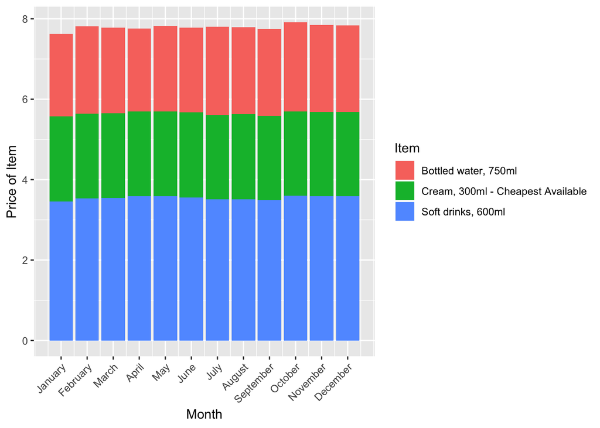

```
Be sure that the months are in the correct order.  (You may need to set `Month` to be a factor with the right order of levels.)  Also be sure that the month labels are not overlapping in the visual display. [8 marks]
```

```r
fp.threeItem = fp.2012 %>%
                filter(Item %in% c(
                  "Bottled water, 750ml",
                  "Cream, 300ml - Cheapest Available",
                  "Soft drinks, 600ml"))
graph = ggplot(fp.threeItem, aes(x=fp.threeItem$Month_num, y = fp.threeItem$Data_value, fill = Item)) + geom_bar(stat = "identity") + labs(x = "Month", y = "Price of Item") + scale_x_continuous(breaks=1:12,labels=c(unique(fp.threeItem$Month)))+theme(axis.text.x = element_text(angle = 45, hjust = 1))
graph
```

**Q3. (9 Marks)**

Copy the following code into your RMarkdown answers file. This code defines a function and then executes that function. Comments provided in the function explain what specific lines of code are meant to do.

Run the code. It should exit with an error. Use the `browser` command or the `R` option `options(error = recover)` to debug the function and find the three mistakes in it. The mistakes may include code that is incorrect, code that needs to be removed, or code that is missing.

If the ‘Stop’ button does not close browser mode, go to the console and use the `Esc` key to escape from browser mode.

For each of the three mistakes, write a comment in your RMarkdown file explaining where you think the bug is and why (2 marks for each bug) and change the code to fix the bug (1 mark for each bug). Partial credit will be given for incomplete answers.

```r
#options(error = recover)
summarise_vehicles <- function(vehicle_df, region, type, max_axles, earliest_year = min(vehicles$VEHICLE_YEAR))
{
    # Ensure that the "dplyr" package is loaded.
    require(dplyr)

    # Check to see if the supplied data frame has variables with names matching those to be used in the function
    if(!all(c("TLA", "VEHICLE_TYPE", "NUMBER_OF_AXLES", "VEHICLE_YEAR", "BASIC_COLOUR", "BODY_TYPE", "MODEL", "MAKE", "CC_RATING", "GROSS_VEHICLE_MASS") %in% names(vehicle_df)))

      stop("The supplied data frame does not contain all variables required for this function to execute correctly.")

    # Check to see if the values for "region" and "type" are valid geographic regions and vehicle types
    if(!(region %in% unique(vehicle_df$TLA)))
        stop(paste(region, "is not in the list of TLAs (regions) in the dataset."))
    if(!(type %in% unique(vehicle_df$VEHICLE_TYPE)))
        stop(paste(type, "is not in the list of vehicle types in the dataset."))

    # Restrict to vehicles from the specified region, of the specified vehicle type, with no more axles than the specified maximum number of axles, and for years starting in the earliest specified year.  Add a new variable that records the decade corresponding to the entry.
    vehicles_sub <- filter(vehicle_df, TLA == region, VEHICLE_TYPE == type, NUMBER_OF_AXLES <= max_axles, NUMBER_OF_CYLINDERS > 3, VEHICLE_YEAR >= earliest_year) %>% mutate(VEHICLE_DECADE = floor(VEHICLE_YEAR / 10) * 10)

    # Restrict to only vehicles that have positive gross vehicle mass.
    vehicles_sub <- filter(vehicles_sub, GROSS_VEHICLE_MASS < 0)

    # Group by make and decade, sorting by vehicle decade, and only include car colour, body type, model, make, decade CC rating, and gross vehicle mass.
    vehicles_sub <- group_by(vehicles_sub, MAKE, VEHICLE_DECADE) %>% arrange(VEHICLE_DECADE) %>% select(BASIC_COLOUR, BODY_type, MODEL, MAKE, VEHICLE_DECADE, CC_RATING, GROSS_VEHICLE_MASS)

    result <- summarise(vehicles_sub, N = n(), Mean_CC_Rating = mean(CC_RATING))

    filter(result, N > 10)
}

vehicles <- as_tibble(read.csv("Motor_Vehicles.csv"))
summarise_vehicles(vehicles, "AUCKLAND", "GOODS VAN/TRUCK/UTILITY", 4, 2000)
```

```
## Error: Problem with `filter()` input `..4`.
## x object 'NUMBER_OF_CYLINDERS' not found
## ℹ Input `..4` is `NUMBER_OF_CYLINDERS > 3`.
```

From the comments " only vehicles that have positive gross vehicle mass." The original code actually try to find vehicles have negative gross vehicle mass, the orginal code is:

```r
#original
vehicles_sub <- filter(vehicles_sub, GROSS_VEHICLE_MASS < 0)

# fixed
vehicles_sub <- filter(vehicles_sub, GROSS_VEHICLE_MASS > 0)
```

Another error is the column name “BODY_TYPE” should be all capital.The original code :

```r
#original:
vehicles_sub <- group_by(vehicles_sub, MAKE, VEHICLE_DECADE) %>% arrange(VEHICLE_DECADE) %>% select(BASIC_COLOUR, BODY_type, MODEL, MAKE, VEHICLE_DECADE, CC_RATING, GROSS_VEHICLE_MASS)

# the "BODY_type" should change to "BODY_TYPE"
vehicles_sub <- group_by(vehicles_sub, MAKE, VEHICLE_DECADE) %>% arrange(VEHICLE_DECADE) %>% select(BASIC_COLOUR, BODY_TYPE, MODEL, MAKE, VEHICLE_DECADE, CC_RATING, GROSS_VEHICLE_MASS)
```

```r
#original
vehicles_sub <- filter(vehicle_df, TLA == region, VEHICLE_TYPE == type, NUMBER_OF_AXLES <= max_axles, NUMBER_OF_CYLINDERS > 3, VEHICLE_YEAR >= earliest_year) %>% mutate(VEHICLE_DECADE = floor(VEHICLE_YEAR / 10) * 10)

# fixed
vehicles_sub <- vehicle_df %>%
  mutate(NUMBER_OF_CYLINDERS= trunc(CC_RATING/500)) %>% # calculate the number of cylinders and round it to the nearest integer
  filter(TLA == region, VEHICLE_TYPE == type, NUMBER_OF_AXLES <= max_axles, NUMBER_OF_CYLINDERS > 3, VEHICLE_YEAR >= earliest_year) %>% mutate(VEHICLE_DECADE = floor(VEHICLE_YEAR / 10) * 10)
```

**(Assignment total: 40 Marks)**